# Simple Linear Regression

```r
# Load your libraries
library(car)
library(DT)
library(tidyverse)
library(pander)
library(mosaic)
library(plotly)
library(ggplot2)

# Load your data after saving a csv file in your Data folder.
# You can use either
Golf_Scores <- read.csv("../../Data/Data Collection - Linear Regression.csv", header=TRUE)
```

## Background

I am an avid golfer, with the goal of beating my Dad at Golf when I go home in August. I have never beaten him, and have only come close on one occassion. In order to beat him, I have been practicing and also collecting golf related data that will give me an advantage in our nexy match.

[figure not shown]

There are many physical factors that influence a golf score- the type of clubs or ball used, the cut of the grass, the firmness or softness of the green or the wind etc. Wind is an influential physical factor that can cause a golfer to use a different club than they normally would use to either hit it further or shorter depending on if the wind is against you or with you respectively.

I collected my scores over the last 10 rounds as well as the wind speed at the exact time I played during each round.

### Original Data

```r
datatable(Golf_Scores)
```

|  | Wind.Speed..mph. | Gross.Score |
| --- | --- | --- |
| 1 | 24.35 | 45 |
| 2 | 12.43 | 44 |
| 3 | 9.32 | 44 |
| 4 | 8.08 | 44 |
| 5 | 6.84 | 40 |
| 6 | 6.84 | 43 |
| 7 | 3.11 | 41 |
| 8 | 16.78 | 39 |
| 9 | 12 | 43 |
| 10 | 12 | 43 |

Does the speed of the wind have a stochastic effect on my golf score?

## Analysis

$$\underbrace{Y_i}_\text{Golf Score} = \beta_0 + \beta_1 \underbrace{X_i}_\text{Wind} + \epsilon_i \quad \text{where} \ \epsilon_i \sim N(0, \sigma^2)$$

The hypotheses for our study concern the slope of the regression model, $\beta_1$. If the slope is zero, then there is not a meaningful relationship between my average golf score and the wind speed during the round.

$$H_0: \beta_1 = 0$$

$$H_a: \beta_1 \neq 0$$

$$\alpha = 0.05$$

## Graphical Summary

The plot below indicates my gross score per round measured against the wind speed on the day. The gross score refers to how many times I hit the golf ball. (i.e a score of 39 would mean I completed 9 holes in 39 hits) The wind speed was recorded at the start of the round. However, it is worth mentioning that the wind speed undoubtedly changed throughout the course of the round.

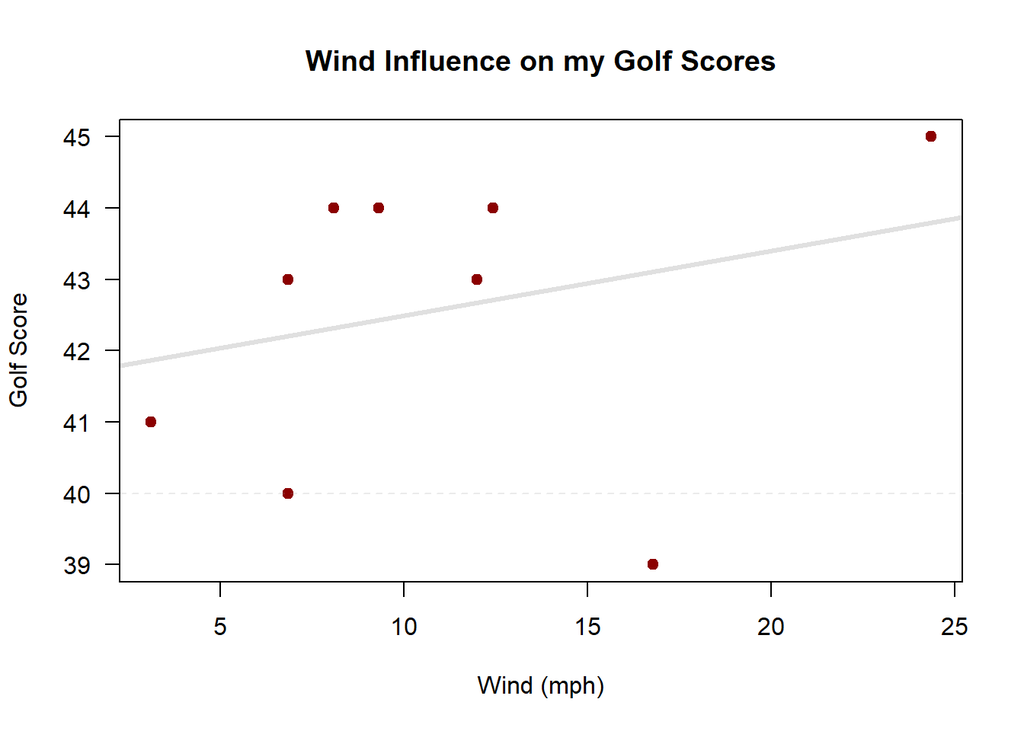

```r
p <- plot(Gross.Score ~ Wind.Speed..mph., data=Golf_Scores, pch=21, bg="darkred", col="darkred",
     xlab="Wind (mph)", ylab="Golf Score",
     main="Wind Influence on my Golf Scores", las=1)
golf.lm <- lm(Gross.Score ~ Wind.Speed..mph., data=Golf_Scores)
abline(golf.lm, lwd=3, col=rgb(.4,.4,.4,.2))
abline(v=seq(40,120,20), h=seq(40,120,20), lty=2, col=rgb(.6,.6,.6,.2))
```

```r
Golf_Scores %>% summarise(cor(Gross.Score ~ Wind.Speed..mph., use="complete.obs"))
```

```
##   cor(Gross.Score ~ Wind.Speed..mph., use = "complete.obs")
## 1                                                 0.2783766
```

```r
ggplotly(p)
```

[output not shown]

The equation of the estimated regression equation from the scatterplot above is given by:

$$\underbrace{\hat{Y}_i}_\text{Mean Golf Score} = 41.59 + 0.0907 \underbrace{X_i}_\text{Wind}$$

The estimated slope of this regression is **0.0907**, which is not significantly different from zero **(p = 0.4361)**. The above equation shows that for every additional mile per hour of wind, my golf score would increase by 0.0907 strokes.

The following table shows the summary of the full regression results.

```r
golf.lm <- lm(Gross.Score ~ Wind.Speed..mph., data=Golf_Scores)
pander(summary(golf.lm))
```

|  | Estimate | Std. Error | t value | Pr(>\|t\|) |
| --- | --- | --- | --- | --- |
| **(Intercept)** | 41.59 | 1.388 | 29.95 | 1.674e-09 |
| **Wind.Speed..mph.** | 0.09077 | 0.1107 | 0.8198 | 0.4361 |

Fitting linear model: Gross.Score ~ Wind.Speed..mph.

| Observations | Residual Std. Error | $R^2$ | Adjusted $R^2$ |
| --- | --- | --- | --- |
| 10 | 1.992 | 0.07749 | -0.03782 |

## Interpretation

The estimated value of the slope is $0.0907$ which shows that on average, there is not a strong correlation between my golf score and the wind. Furthermore, the p-value (**p = 0.4361**) shows that the slope is not significant. Hence, the relationship between my golf scores and the speed of the wind is not meaningful.

## Appropriateness of the above Regression

Due to the below visual regression assumptions, a linear regression is not completely appropriate for this test.

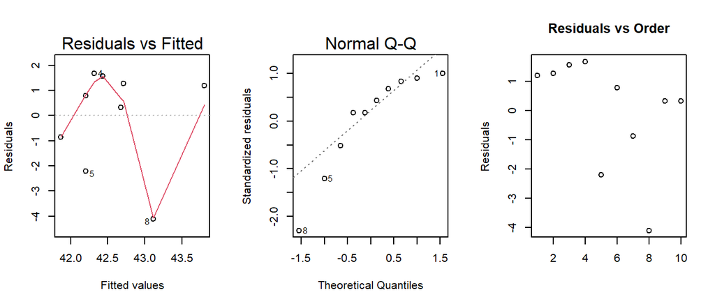

```r
par(mfrow=c(1,3))
plot(golf.lm, which=1:2)
plot(golf.lm$residuals, main="Residuals vs Order", xlab="",
     ylab="Residuals")
```